# Data Visualization - Mini-Project 1

# State Course Description VS. Institution Course Description

## State Course Description Analysis

##### Performing Tokenization and Removing Stop Words

```r
tidy_description_st <- CourseInventory %>%
  unnest_tokens(word, Course_Desc) %>%
  anti_join(stop_words)
```

##### Looking at the most common words in the descriptions for the course.

```r
tidy_description_st %>%
  count(word, sort = TRUE)
```

| word | n |
| --- | --- |
| vary | 7320 |
| students | 5926 |
| topics | 4744 |
| hours | 4590 |
| systems | 3826 |
| design | 3317 |
| institution | 3182 |
| analysis | 2812 |
| management | 2765 |
| levels | 2415 |

[output cut: 990 more lines]

##### Visualizing the most common words.

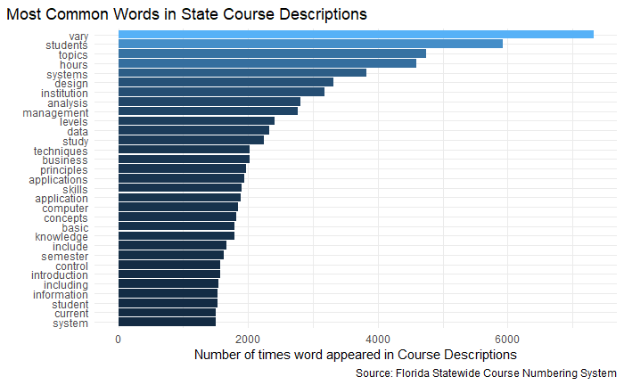

```r
tidy_description_st %>%
  count(word, sort = TRUE) %>%
  filter(n >= 1500) %>%
  mutate(word = reorder(word, n)) %>%
  ggplot(aes(n, word, fill = n)) +
  geom_col(show.legend = FALSE) +
  theme_minimal() +
  labs(x = "Number of times word appeared in Course Descriptions",
       y = "",
       title = "Most Common Words in State Course Descriptions",
       caption = "Source: Florida Statewide Course Numbering System") +
  theme(plot.title.position = "plot")
```

## Institution Course Description Analysis

##### Performing Tokenization and Removing Stop Words

```r
tidy_description_inst <- CourseInventory %>%
  unnest_tokens(word, Inst_Course_Desc) %>%
  anti_join(stop_words)
```

##### Looking at the most common words in the descriptions for the course.

```r
tidy_description_inst %>%
  count(word, sort = TRUE)
```

| word | n |
| --- | --- |
| students | 6140 |
| systems | 3939 |
| design | 3660 |
| management | 3213 |
| topics | 2896 |
| analysis | 2613 |
| data | 2509 |
| include | 2198 |
| computer | 2133 |
| techniques | 2132 |

[output cut: 990 more lines]

##### Visualizing the most common words.

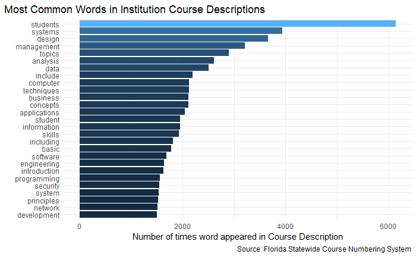

```r
tidy_description_inst %>%
  count(word, sort = TRUE) %>%
  filter(!is.na(word)) %>%
  filter(n >= 1500) %>%
  mutate(word = reorder(word, n,)) %>%
  ggplot(aes(n, word, fill = n)) +
  geom_col(show.legend = FALSE) +
  theme_minimal() +
  labs(x = "Number of times word appeared in Course Description",
       y = "",
       title = "Most Common Words in Institution Course Descriptions",
       caption = "Source: Florida Statewide Course Numbering System") +
  theme(plot.title.position = "plot")
```

After removing stop-words and performing tokenization, I definitely feel like I could have created a dictionary to also remove words like student, students, vary, information, etc. That being said can see that bigger terms like systems, management, and data were most popular. This could help students and administration understand specific topics that these courses would be teaching and help either determine what topics you might be interested in to determine if these STEM Disciplines are right for you.